# Analysis of Private Healthcare Information Network Data

Sebastien Peytrignet

2023-04-19

## Data considerations

- This dataset is provided by the The Private Healthcare Information Network (PHIN), who are mandated to report activity data on privately-funded health care under competition and consumer protection laws.
- This dataset also reports activity funded by the NHS for the purpose of comparing NHS-funded to privately-funded activity. Some NHS-funded activity data is in fact delivered by independent sector providers, but this appears as NHS activity in this data because activity is classified by source of funding.
- There have been [concerns](https://www.computerweekly.com/news/252528354/Private-health-provider-data-could-be-shared-with-NHS-England) about private providers submitting [incomplete data](https://www.gov.uk/government/news/action-against-private-hospitals-to-boost-patients-access-to-information) to PHIN.

## What are the highest-volume NHS and IS/private procedures?

- Therapeutics (chemotherapy, IV drug infusions), upper GI endoscopies, dialysis and colonoscopies are the highest-volume NHS-funded procedures
- The independent sector also does many cataract surgeries, and hip and knee replacements

| procedure_group | private_procedures | nhs_procedures |
| --- | --- | --- |
| Other procedure | 99,860 | 1,023,190 |
| Therapeutics - chemotherapy | 69,190 | 908,085 |
| Therapeutics - intravenous drug infusion | 8,020 | 595,290 |
| Diagnostic upper GI endoscopy | 40,085 | 484,145 |
| Diagnostic colonoscopy - bowel | 34,035 | 318,360 |
| Therapeutics - haemodialysis | 325 | 343,910 |
| Cataract surgery | 64,965 | 228,160 |
| Diagnostics - blood test | 2,680 | 243,035 |
| Therapeutic colonoscopy - bowel | 11,370 | 175,910 |
| Therapeutics - blood product transfusion | 3,805 | 143,060 |
| Bladder examination - diagnostic endoscopy (cystoscopy) | 13,335 | 90,610 |
| Hip replacement (primary) | 25,945 | 49,150 |
| Epidural injection | 19,205 | 49,775 |
| Knee replacement (primary) | 15,665 | 47,165 |
| Knee arthroscopy | 19,505 | 30,020 |

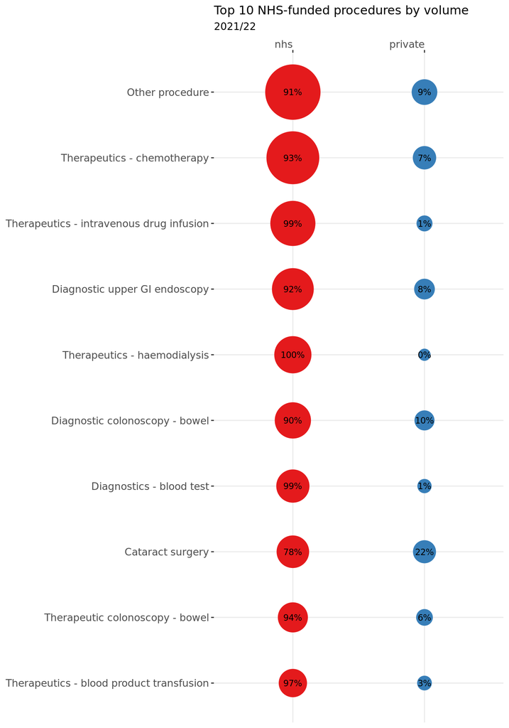

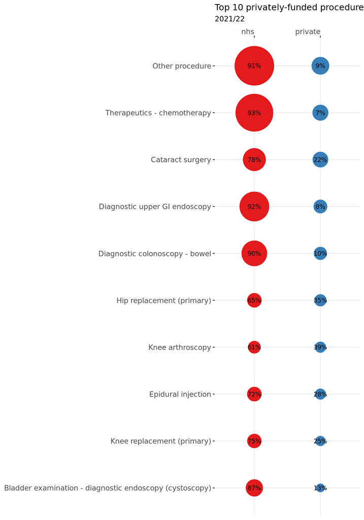

## Where did the independent sector add the most treatments in 2021/22 compared to 2020/21? Did it disrupt the NHS/private mix for those treatment groups?

- In the past year, cataracts, endoscopies, hip replacements and colonoscopies is where the independent sector has added the most treatments
- But this hasn’t resulted in large changes in the relative NHS/private funding mix, because the NHS has also grown in those treatment areas

| procedure_group | type | delta |
| --- | --- | --- |
| Other procedure | delta_private | 39025 |
| Cataract surgery | delta_private | 26650 |
| Diagnostic upper GI endoscopy | delta_private | 13985 |
| Hip replacement (primary) | delta_private | 11645 |
| Diagnostic colonoscopy - bowel | delta_private | 11610 |

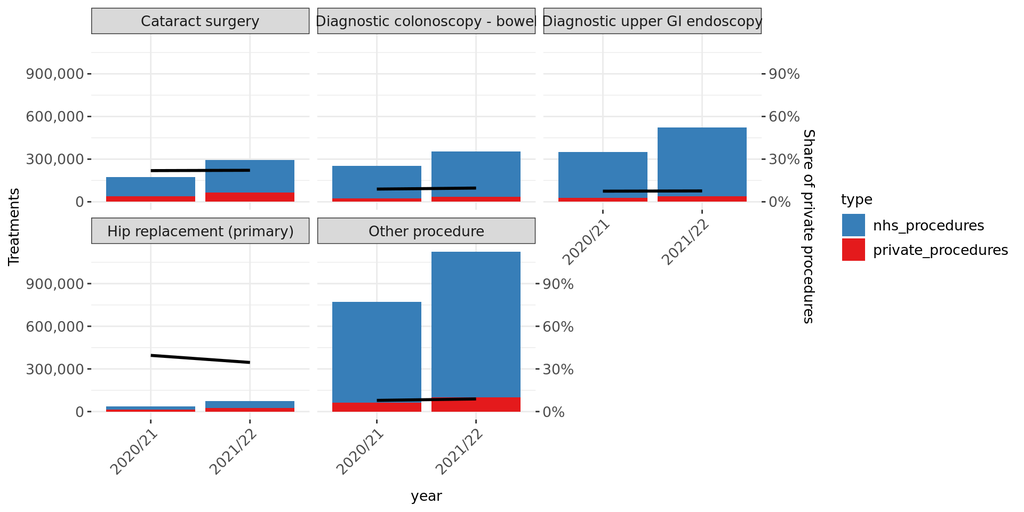

## Complexity: do independent sector patients have shorter stays compated to NHS funded?

- The majority of procedures are carried out more quickly in the NHS compared to the independent sector, measured by how many are done as day-cases
- This may be driven by case mix, or because of available resources or number of beds

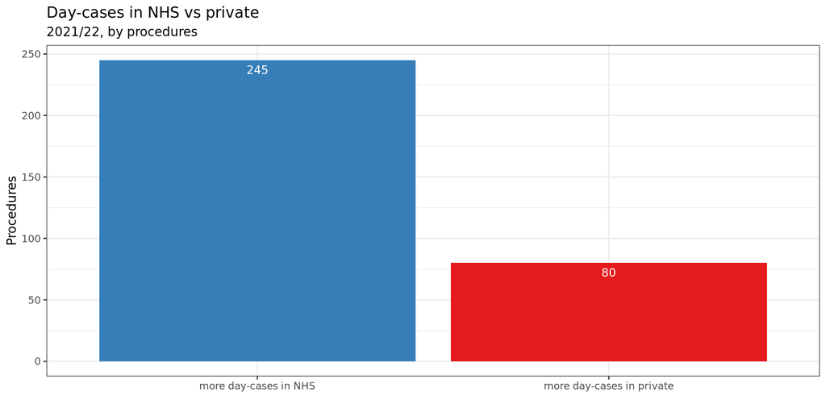

## Which procedures does the NHS do quicker?

- Some procedures have a much shorter length-of-stay in the NHS, e.g. radiotherapy is almost always done as a day-case in NHS but usually with an overnight stay in the independent sector

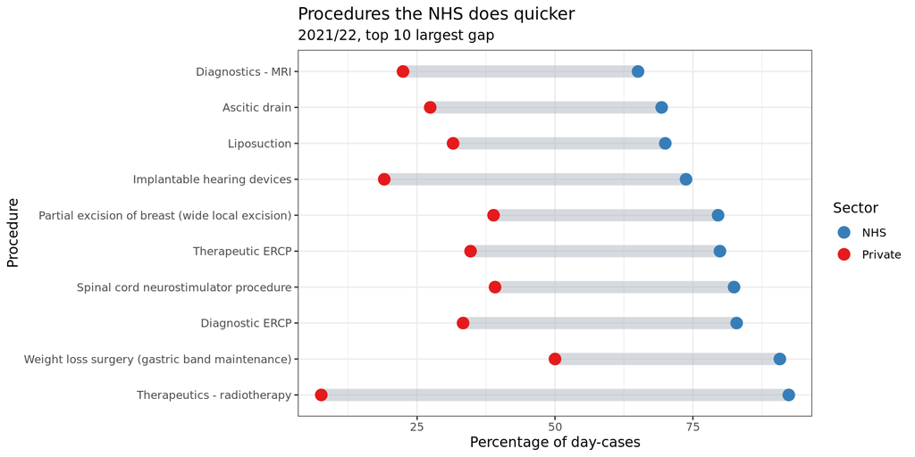

## Which procedures does the independent sector do quicker?

- Some procedures are done a lot more quickly in the independent sector, e.g. weight loss surgery.

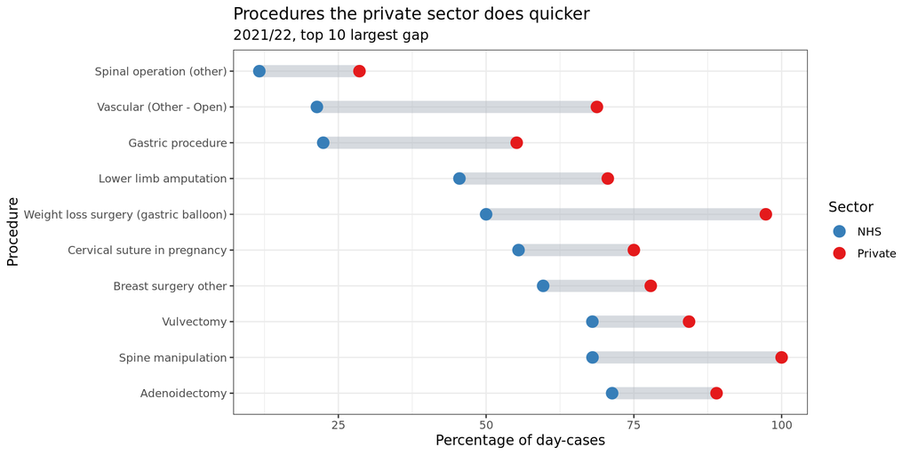